# Linear regression: before and after fitting

Jeffrey Chrabaszcz  
8 January 2015

### Outline

1. Dummy coding
2. Linear transformations
3. Centering and standardizing
4. Correlation & “regression to the mean”
5. Logarithmic transformations
6. Discretizing continuous data
7. Building models for prediction
8. A quick note on time-series analyses

### Dummy coding

Using categorical predictors in linear models can be confusing. This is because for each categorical input, we actually add the number of levels - 1 new parameters to the model.

| x1 | x11 | x12 | x13 |
| --- | --- | --- | --- |
| 1 | 0 | 0 | 0 |
| 2 | 1 | 0 | 0 |
| 3 | 0 | 1 | 0 |
| 4 | 0 | 0 | 1 |

This particular scheme, treatment coding, is the R default and only one we'll be discussing.

```
Call:
lm(formula = count ~ spray, data = InsectSprays)

Residuals:
   Min     1Q Median     3Q    Max
 -8.33  -1.96  -0.50   1.67   9.33

Coefficients:
            Estimate Std. Error t value Pr(>|t|)
(Intercept)   14.500      1.132   12.81  < 2e-16 ***
sprayB         0.833      1.601    0.52     0.60
sprayC       -12.417      1.601   -7.76  7.3e-11 ***
sprayD        -9.583      1.601   -5.99  9.8e-08 ***
sprayE       -11.000      1.601   -6.87  2.8e-09 ***
sprayF         2.167      1.601    1.35     0.18
---
Signif. codes:  0 '***' 0.001 '**' 0.01 '*' 0.05 '.' 0.1 ' ' 1

Residual standard error: 3.92 on 66 degrees of freedom
Multiple R-squared:  0.724, Adjusted R-squared:  0.704
F-statistic: 34.7 on 5 and 66 DF,  p-value: <2e-16
```

```
Call:
lm(formula = count ~ spray, data = InsectSprays)

Residuals:
   Min     1Q Median     3Q    Max
 -8.33  -1.96  -0.50   1.67   9.33

Coefficients:
            Estimate Std. Error t value Pr(>|t|)
(Intercept)     2.08       1.13    1.84    0.070 .
sprayA         12.42       1.60    7.76  7.3e-11 ***
sprayB         13.25       1.60    8.28  8.5e-12 ***
sprayD          2.83       1.60    1.77    0.081 .
sprayE          1.42       1.60    0.88    0.379
sprayF         14.58       1.60    9.11  2.8e-13 ***
---
Signif. codes:  0 '***' 0.001 '**' 0.01 '*' 0.05 '.' 0.1 ' ' 1

Residual standard error: 3.92 on 66 degrees of freedom
Multiple R-squared:  0.724, Adjusted R-squared:  0.704
F-statistic: 34.7 on 5 and 66 DF,  p-value: <2e-16
```

### Insect graph

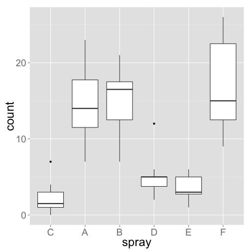

```r
ggplot(InsectSprays, aes(spray, count)) + geom_boxplot() + theme_grey(base_size = 24)
```

### Linear transformation

Linear transformations have no effect on model fit, but can improve interpretability of the model.

- add a constant
- multiply by a constant
- both!

This is because any of these operations maintain the ratio between points.

### Common transformations

## mean centering

- subtract mean(x) from each value of x
- intercept term now meaningful
- use when the units of your outcome are meaningful

## z transformation

\[ z_x = \frac{x_i - \bar{x}}{\sigma_x} \]

- 0 point is now the mean of x
- unit change corresponds to a one standard deviation change

```
lm(formula = kid_score ~ mom_hs * mom_iq, data = df)
              coef.est coef.se
(Intercept)   -11.48    13.76
mom_hs         51.27    15.34
mom_iq          0.97     0.15
mom_hs:mom_iq  -0.48     0.16
---
n = 434, k = 4
residual sd = 17.97, R-Squared = 0.23
```

```
lm(formula = kid_score ~ mom_hs * c.mom.iq, data = df)
                coef.est coef.se
(Intercept)     85.41     2.22
mom_hs           2.84     2.43
c.mom.iq        14.53     2.23
mom_hs:c.mom.iq -7.26     2.43
---
n = 434, k = 4
residual sd = 17.97, R-Squared = 0.23
```

### Correlation and "regression to the mean"

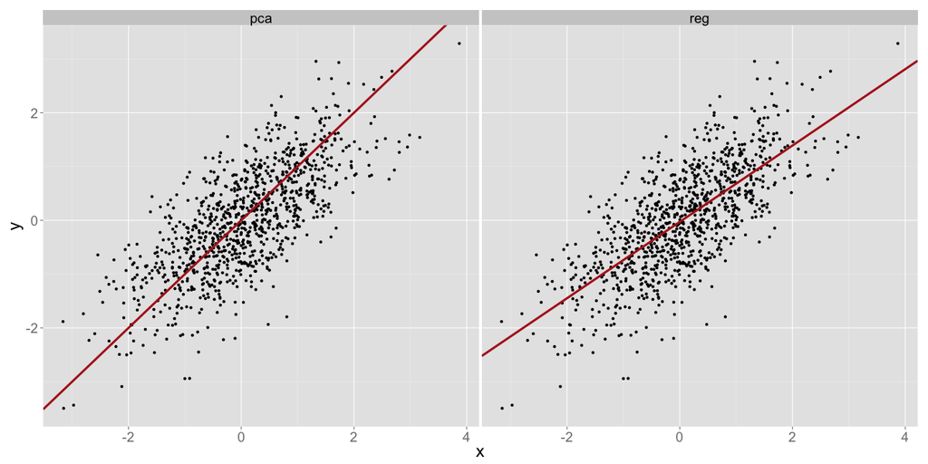

### Logarithmic function

\[ log(a \cdot b) = log(a) + log(b) \]

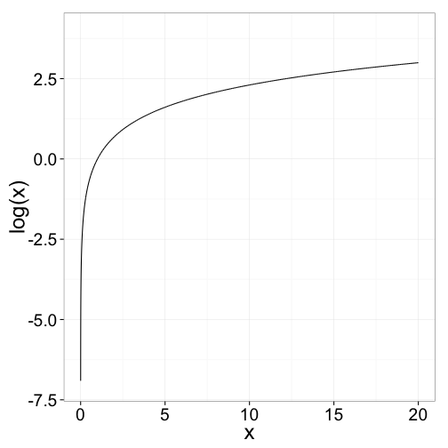

### Logarithmic tranformations

- Proportional change
- only works for all values > 0

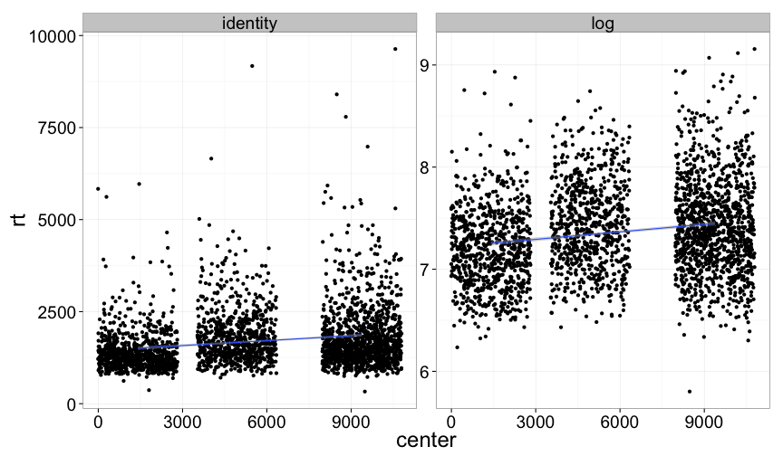

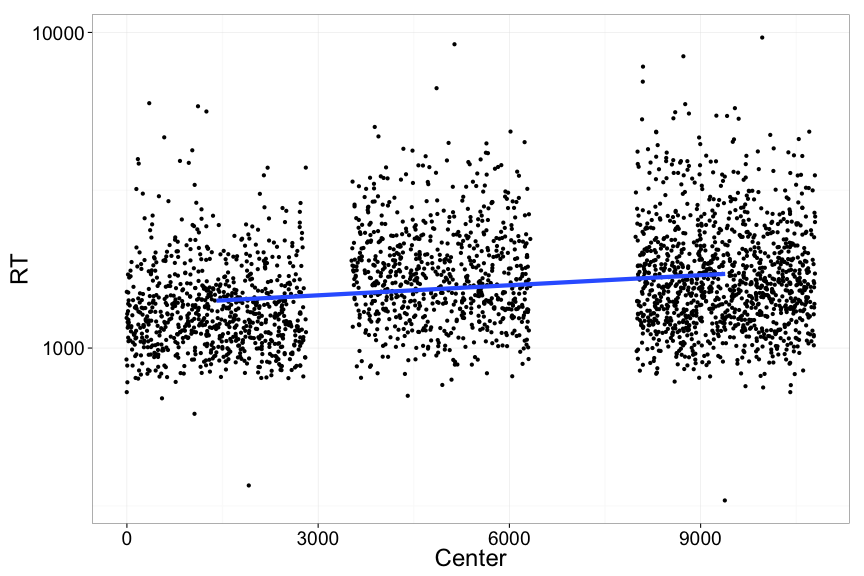

```r
ggplot(a, aes(Center, RT)) + geom_jitter() + geom_smooth(method = "lm", size = 2, se = FALSE) + scale_y_log10() + theme_bw(base_size = 24)
```

### Discretizing continuous data

In general, don't do this unless you have an obvious, justifiable non-linearity or you need to visualize and interaction.

```r
juul$post <- factor(ifelse(juul$tanner > 1, 1, 0))
display(lm(igf1 ~ age * post, data = juul))
```

```
lm(formula = igf1 ~ age * post, data = juul)
            coef.est coef.se
(Intercept)  76.48    18.34
age          16.08     2.10
post1       496.60    25.13
age:post1   -23.23     2.33
---
n = 792, k = 4
residual sd = 115.32, R-Squared = 0.56
```

### Visual analogue

[figure not shown]

### Building models for prediction

Gelman's rules for including predictors:

- expected sign and “significant”
- unexpected sign and “significant”
- expected sign and not-significant
- remove a predictor IFF unexpected sign and n.s. (but investigate the data first)

Why? Because we're not getting point estimates, we're getting distributions. Type-M and Type-S errors rather than Type-I and Type-II errors.

### Model comparison

Similar to adjusted \( R^2 \), there are other ways to calculate penalized fit.

- Deviance
  - \( -2(log(p(y|\hat{\theta_0})) - log(p(y|\hat{\theta_s}))) \)
- BIC
  - \( n \cdot log(1 - R^2) + k\cdot log(n) \)
- AIC
  - \( n \cdot log(1 - R^2) + 2 \cdot k \)
- Many, many others

### A quick note on time-series analysis

Times-series data can provide incredibly rich analyses. However:

- errors are generally not independent
- linearity is often violated
- in a linear modeling context, number of parameters can quickly become intractable

Consider a dataset with two years worth of data with measures taken every month. Unless you expect a perfectly linear trend for your outcome with no change in predictors over time, you likely have to add a minimum of 24 new parameters. This number immediately jumps to 48 if you investigate a single continuous interaction.